# Optimal Treatment Analysis

## Outcome Variable

**Outcome Variable:** haz

## Predictor Variables

**Intervention Variable:** rain_quartile

**Adjustment Set:**

unadjusted

## Stratifying Variables

The analysis was stratified on these variable(s):

- studyid
- country
- agecat

## Data Summary

| studyid | country | agecat | rain_quartile | n_cell | n |
| --- | --- | --- | --- | --- | --- |
| CMC-V-BCS-2002 | India | Birth | 1 | 18 | 92 |
| CMC-V-BCS-2002 | India | Birth | 2 | 25 | 92 |
| CMC-V-BCS-2002 | India | Birth | 3 | 30 | 92 |
| CMC-V-BCS-2002 | India | Birth | 4 | 19 | 92 |
| CMC-V-BCS-2002 | India | 6 months | 1 | 101 | 369 |
| CMC-V-BCS-2002 | India | 6 months | 2 | 111 | 369 |
| CMC-V-BCS-2002 | India | 6 months | 3 | 97 | 369 |
| CMC-V-BCS-2002 | India | 6 months | 4 | 60 | 369 |
| CMC-V-BCS-2002 | India | 24 months | 1 | 87 | 333 |
| CMC-V-BCS-2002 | India | 24 months | 2 | 90 | 333 |
| CMC-V-BCS-2002 | India | 24 months | 3 | 94 | 333 |
| CMC-V-BCS-2002 | India | 24 months | 4 | 62 | 333 |
| CMIN | Bangladesh | Birth | 1 | 7 | 26 |
| CMIN | Bangladesh | Birth | 2 | 6 | 26 |
| CMIN | Bangladesh | Birth | 3 | 6 | 26 |
| CMIN | Bangladesh | Birth | 4 | 7 | 26 |
| CMIN | Bangladesh | 6 months | 1 | 50 | 243 |
| CMIN | Bangladesh | 6 months | 2 | 62 | 243 |
| CMIN | Bangladesh | 6 months | 3 | 71 | 243 |
| CMIN | Bangladesh | 6 months | 4 | 60 | 243 |
| CMIN | Bangladesh | 24 months | 1 | 72 | 224 |
| CMIN | Bangladesh | 24 months | 2 | 64 | 224 |
| CMIN | Bangladesh | 24 months | 3 | 52 | 224 |
| CMIN | Bangladesh | 24 months | 4 | 36 | 224 |
| CONTENT | Peru | Birth | 1 | 0 | 2 |
| CONTENT | Peru | Birth | 2 | 2 | 2 |
| CONTENT | Peru | Birth | 3 | 0 | 2 |
| CONTENT | Peru | Birth | 4 | 0 | 2 |
| CONTENT | Peru | 6 months | 1 | 62 | 215 |
| CONTENT | Peru | 6 months | 2 | 32 | 215 |

[output cut: 238 more lines]

The following strata were considered:

- studyid: CMC-V-BCS-2002, country: India, agecat: 24 months
- studyid: CMC-V-BCS-2002, country: India, agecat: 6 months
- studyid: CMC-V-BCS-2002, country: India, agecat: Birth
- studyid: CMIN, country: Bangladesh, agecat: 24 months
- studyid: CMIN, country: Bangladesh, agecat: 6 months
- studyid: CMIN, country: Bangladesh, agecat: Birth
- studyid: CONTENT, country: Peru, agecat: 24 months
- studyid: CONTENT, country: Peru, agecat: 6 months
- studyid: CONTENT, country: Peru, agecat: Birth
- studyid: EE, country: Pakistan, agecat: 24 months
- studyid: EE, country: Pakistan, agecat: 6 months
- studyid: EE, country: Pakistan, agecat: Birth
- studyid: GMS-Nepal, country: Nepal, agecat: 24 months
- studyid: GMS-Nepal, country: Nepal, agecat: 6 months
- studyid: GMS-Nepal, country: Nepal, agecat: Birth
- studyid: Guatemala BSC, country: Guatemala, agecat: 6 months
- studyid: IRC, country: India, agecat: 24 months
- studyid: IRC, country: India, agecat: 6 months
- studyid: IRC, country: India, agecat: Birth
- studyid: JiVitA-3, country: Bangladesh, agecat: 24 months
- studyid: JiVitA-3, country: Bangladesh, agecat: 6 months
- studyid: JiVitA-3, country: Bangladesh, agecat: Birth
- studyid: JiVitA-4, country: Bangladesh, agecat: 24 months
- studyid: JiVitA-4, country: Bangladesh, agecat: 6 months
- studyid: JiVitA-4, country: Bangladesh, agecat: Birth
- studyid: Keneba, country: Gambia, agecat: 24 months
- studyid: Keneba, country: Gambia, agecat: 6 months
- studyid: Keneba, country: Gambia, agecat: Birth
- studyid: LCNI-5, country: Malawi, agecat: 24 months
- studyid: LCNI-5, country: Malawi, agecat: 6 months
- studyid: MAL-ED, country: Bangladesh, agecat: 24 months
- studyid: MAL-ED, country: Bangladesh, agecat: 6 months
- studyid: MAL-ED, country: Bangladesh, agecat: Birth
- studyid: MAL-ED, country: Brazil, agecat: 24 months
- studyid: MAL-ED, country: Brazil, agecat: 6 months
- studyid: MAL-ED, country: Brazil, agecat: Birth
- studyid: MAL-ED, country: India, agecat: 24 months
- studyid: MAL-ED, country: India, agecat: 6 months
- studyid: MAL-ED, country: India, agecat: Birth
- studyid: MAL-ED, country: Nepal, agecat: 24 months
- studyid: MAL-ED, country: Nepal, agecat: 6 months
- studyid: MAL-ED, country: Nepal, agecat: Birth
- studyid: MAL-ED, country: Peru, agecat: 24 months
- studyid: MAL-ED, country: Peru, agecat: 6 months
- studyid: MAL-ED, country: Peru, agecat: Birth
- studyid: MAL-ED, country: South Africa, agecat: 24 months
- studyid: MAL-ED, country: South Africa, agecat: 6 months
- studyid: MAL-ED, country: South Africa, agecat: Birth
- studyid: MAL-ED, country: Tanzania, agecat: 24 months
- studyid: MAL-ED, country: Tanzania, agecat: 6 months
- studyid: MAL-ED, country: Tanzania, agecat: Birth
- studyid: PROBIT, country: Belarus, agecat: 24 months
- studyid: PROBIT, country: Belarus, agecat: 6 months
- studyid: PROBIT, country: Belarus, agecat: Birth
- studyid: PROVIDE, country: Bangladesh, agecat: 24 months
- studyid: PROVIDE, country: Bangladesh, agecat: 6 months
- studyid: PROVIDE, country: Bangladesh, agecat: Birth
- studyid: ResPak, country: Pakistan, agecat: 6 months
- studyid: ResPak, country: Pakistan, agecat: Birth
- studyid: SAS-CompFeed, country: India, agecat: 6 months
- studyid: SAS-CompFeed, country: India, agecat: Birth
- studyid: SAS-FoodSuppl, country: India, agecat: 6 months
- studyid: TanzaniaChild2, country: Tanzania, agecat: 24 months
- studyid: TanzaniaChild2, country: Tanzania, agecat: 6 months
- studyid: ZVITAMBO, country: Zimbabwe, agecat: 24 months
- studyid: ZVITAMBO, country: Zimbabwe, agecat: 6 months
- studyid: ZVITAMBO, country: Zimbabwe, agecat: Birth

### Dropped Strata

Some strata were dropped due to rare outcomes:

- studyid: CONTENT, country: Peru, agecat: Birth
- studyid: EE, country: Pakistan, agecat: Birth
- studyid: EE, country: Pakistan, agecat: 6 months
- studyid: EE, country: Pakistan, agecat: 24 months
- studyid: GMS-Nepal, country: Nepal, agecat: Birth
- studyid: GMS-Nepal, country: Nepal, agecat: 6 months
- studyid: GMS-Nepal, country: Nepal, agecat: 24 months
- studyid: JiVitA-3, country: Bangladesh, agecat: 24 months
- studyid: PROVIDE, country: Bangladesh, agecat: 24 months
- studyid: ResPak, country: Pakistan, agecat: Birth
- studyid: TanzaniaChild2, country: Tanzania, agecat: 24 months

## Methods Detail

We’re interested in the causal parameters $E[Y_a]$ for all values of $a \in \mathcal{A}$. These parameters represent the mean outcome if, possibly contrary to fact, we intervened to set all units to have $A=a$. Under the randomization and positivity assumptions, these are identified by the statistical parameters $\psi_a=E_W[E_{Y|A,W}(Y|A=a,W)]$. In addition, we’re interested in the mean of $Y$, $E[Y]$ under no intervention (the observed mean). We will estimate these parameters by using SuperLearner to fit the relevant likelihood factors – $E_{Y|A,W}(Y|A=a,W)$ and $p(A=a|W)$, and then updating our likelihood fit using a joint TMLE.

For unadjusted analyses ($W=\{\}$), initial likelihoods were estimated using Lrnr_glm to estimate the simple $E(Y|A)$ and Lrnr_mean to estimate $p(A)$. For adjusted analyses, a small library containing Lrnr_glmnet, Lrnr_xgboost, and Lrnr_mean was used.

Having estimated these parameters, we will then use the delta method to estimate relative risks and attributable risks relative to a prespecified baseline level of $A$.

# Results Detail

## Results Plots

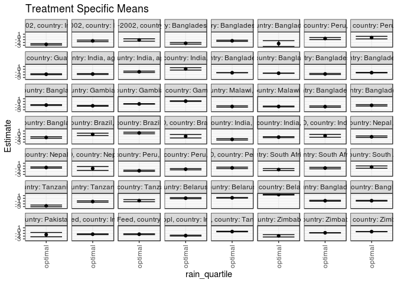

## Results Table

### Parameter: TSM

| studyid | country | agecat | intervention_level | baseline_level | estimate | ci_lower | ci_upper |
| --- | --- | --- | --- | --- | --- | --- | --- |
| CMC-V-BCS-2002 | India | Birth | optimal | observed | -1.0916300 | -1.5195698 | -0.6636901 |
| CMC-V-BCS-2002 | India | 6 months | optimal | observed | -1.4141077 | -1.6871387 | -1.1410767 |
| CMC-V-BCS-2002 | India | 24 months | optimal | observed | -2.6856936 | -2.9285760 | -2.4428112 |
| CMIN | Bangladesh | Birth | optimal | observed | -2.3965174 | -3.4563683 | -1.3366664 |
| CMIN | Bangladesh | 6 months | optimal | observed | -1.3857082 | -1.6013262 | -1.1700903 |
| CMIN | Bangladesh | 24 months | optimal | observed | -2.2966451 | -2.5852398 | -2.0080505 |
| CONTENT | Peru | 6 months | optimal | observed | -0.2309975 | -0.7005123 | 0.2385174 |
| CONTENT | Peru | 24 months | optimal | observed | -0.5748075 | -0.9623697 | -0.1872454 |
| Guatemala BSC | Guatemala | 6 months | optimal | observed | -1.8025272 | -1.9788140 | -1.6262404 |
| IRC | India | Birth | optimal | observed | 0.1291667 | -0.3092709 | 0.5676044 |
| IRC | India | 6 months | optimal | observed | -0.9233461 | -1.1824977 | -0.6641946 |
| IRC | India | 24 months | optimal | observed | -1.7363212 | -1.9249528 | -1.5476897 |
| JiVitA-3 | Bangladesh | Birth | optimal | observed | -1.4500283 | -1.4876148 | -1.4124418 |
| JiVitA-3 | Bangladesh | 6 months | optimal | observed | -1.2694846 | -1.3124730 | -1.2264962 |
| JiVitA-4 | Bangladesh | Birth | optimal | observed | -1.2891525 | -1.4228953 | -1.1554097 |
| JiVitA-4 | Bangladesh | 6 months | optimal | observed | -1.2383888 | -1.3201665 | -1.1566110 |
| JiVitA-4 | Bangladesh | 24 months | optimal | observed | -1.7123938 | -1.9162783 | -1.5085092 |
| Keneba | Gambia | Birth | optimal | observed | 0.1372922 | 0.0158699 | 0.2587144 |
| Keneba | Gambia | 6 months | optimal | observed | -0.8714149 | -0.9620403 | -0.7807894 |
| Keneba | Gambia | 24 months | optimal | observed | -1.5616236 | -1.7218712 | -1.4013761 |
| LCNI-5 | Malawi | 6 months | optimal | observed | -1.8078422 | -1.9629329 | -1.6527515 |
| LCNI-5 | Malawi | 24 months | optimal | observed | -1.8030623 | -2.0393221 | -1.5668025 |
| MAL-ED | Bangladesh | Birth | optimal | observed | -1.3451259 | -1.6254043 | -1.0648475 |
| MAL-ED | Bangladesh | 6 months | optimal | observed | -1.3825117 | -1.6284596 | -1.1365637 |
| MAL-ED | Bangladesh | 24 months | optimal | observed | -1.8516770 | -2.1033590 | -1.5999951 |
| MAL-ED | Brazil | Birth | optimal | observed | -0.8909925 | -1.5155466 | -0.2664383 |
| MAL-ED | Brazil | 6 months | optimal | observed | 0.2944034 | 0.0209790 | 0.5678278 |
| MAL-ED | Brazil | 24 months | optimal | observed | -0.2027103 | -0.6227876 | 0.2173670 |
| MAL-ED | India | Birth | optimal | observed | -0.7386748 | -1.2472378 | -0.2301118 |
| MAL-ED | India | 6 months | optimal | observed | -1.2152574 | -1.4111099 | -1.0194049 |
| MAL-ED | India | 24 months | optimal | observed | -2.0291608 | -2.2758615 | -1.7824602 |
| MAL-ED | Nepal | Birth | optimal | observed | -0.8864650 | -1.5981312 | -0.1747989 |
| MAL-ED | Nepal | 6 months | optimal | observed | -0.5348087 | -0.7621742 | -0.3074433 |
| MAL-ED | Nepal | 24 months | optimal | observed | -1.0773505 | -1.3663937 | -0.7883073 |
| MAL-ED | Peru | Birth | optimal | observed | -0.6617961 | -0.9216245 | -0.4019678 |
| MAL-ED | Peru | 6 months | optimal | observed | -1.1495373 | -1.3875049 | -0.9115696 |
| MAL-ED | Peru | 24 months | optimal | observed | -1.6943741 | -1.9010998 | -1.4876483 |
| MAL-ED | South Africa | Birth | optimal | observed | -0.3728911 | -0.7919314 | 0.0461493 |
| MAL-ED | South Africa | 6 months | optimal | observed | -0.7297567 | -1.0147052 | -0.4448081 |
| MAL-ED | South Africa | 24 months | optimal | observed | -1.2689513 | -1.6312564 | -0.9066462 |
| MAL-ED | Tanzania | Birth | optimal | observed | -0.8484674 | -1.2354549 | -0.4614799 |
| MAL-ED | Tanzania | 6 months | optimal | observed | -1.1662089 | -1.4251271 | -0.9072907 |
| MAL-ED | Tanzania | 24 months | optimal | observed | -2.7402262 | -3.0531217 | -2.4273307 |
| PROBIT | Belarus | Birth | optimal | observed | 1.3768311 | 1.2078710 | 1.5457912 |
| PROBIT | Belarus | 6 months | optimal | observed | 0.1889879 | 0.0811306 | 0.2968452 |
| PROBIT | Belarus | 24 months | optimal | observed | 0.0530883 | -0.1360938 | 0.2422704 |
| PROVIDE | Bangladesh | Birth | optimal | observed | -0.8643516 | -1.0085157 | -0.7201876 |
| PROVIDE | Bangladesh | 6 months | optimal | observed | -0.8704277 | -1.0451022 | -0.6957533 |
| ResPak | Pakistan | 6 months | optimal | observed | -1.4644412 | -2.2396330 | -0.6892494 |
| SAS-CompFeed | India | Birth | optimal | observed | -1.3137866 | -1.4624821 | -1.1650912 |
| SAS-CompFeed | India | 6 months | optimal | observed | -1.3085853 | -1.4410899 | -1.1760808 |
| SAS-FoodSuppl | India | 6 months | optimal | observed | -1.8068822 | -1.9773983 | -1.6363661 |
| TanzaniaChild2 | Tanzania | 6 months | optimal | observed | -0.3493113 | -0.4536332 | -0.2449894 |
| ZVITAMBO | Zimbabwe | Birth | optimal | observed | -0.3649692 | -0.4030818 | -0.3268565 |
| ZVITAMBO | Zimbabwe | 6 months | optimal | observed | -0.7947033 | -0.8457095 | -0.7436972 |
| ZVITAMBO | Zimbabwe | 24 months | optimal | observed | -1.8901130 | -2.3220909 | -1.4581352 |

### Parameter: E(Y)

| studyid | country | agecat | intervention_level | baseline_level | estimate | ci_lower | ci_upper |
| --- | --- | --- | --- | --- | --- | --- | --- |
| CMC-V-BCS-2002 | India | Birth | observed | observed | -0.9611957 | -1.1776967 | -0.7446946 |
| CMC-V-BCS-2002 | India | 6 months | observed | observed | -1.4234508 | -1.5645974 | -1.2823042 |
| CMC-V-BCS-2002 | India | 24 months | observed | observed | -2.6927477 | -2.7980658 | -2.5874297 |
| CMIN | Bangladesh | Birth | observed | observed | -1.8811538 | -2.5124807 | -1.2498270 |
| CMIN | Bangladesh | 6 months | observed | observed | -1.7844376 | -1.9222926 | -1.6465825 |
| CMIN | Bangladesh | 24 months | observed | observed | -2.5563616 | -2.6853113 | -2.4274119 |
| CONTENT | Peru | 6 months | observed | observed | -0.3139217 | -0.4868486 | -0.1409948 |
| CONTENT | Peru | 24 months | observed | observed | -0.6962195 | -0.8674103 | -0.5250287 |
| Guatemala BSC | Guatemala | 6 months | observed | observed | -1.5619008 | -1.6727702 | -1.4510313 |
| IRC | India | Birth | observed | observed | -0.3080412 | -0.4687931 | -0.1472894 |
| IRC | India | 6 months | observed | observed | -1.2344062 | -1.3658524 | -1.1029600 |
| IRC | India | 24 months | observed | observed | -1.8787176 | -1.9805661 | -1.7768691 |
| JiVitA-3 | Bangladesh | Birth | observed | observed | -1.5894148 | -1.6086362 | -1.5701935 |
| JiVitA-3 | Bangladesh | 6 months | observed | observed | -1.3130932 | -1.3362359 | -1.2899505 |
| JiVitA-4 | Bangladesh | Birth | observed | observed | -1.5232908 | -1.5723277 | -1.4742539 |
| JiVitA-4 | Bangladesh | 6 months | observed | observed | -1.3447940 | -1.3820261 | -1.3075620 |
| JiVitA-4 | Bangladesh | 24 months | observed | observed | -1.9327943 | -1.9977741 | -1.8678145 |
| Keneba | Gambia | Birth | observed | observed | 0.0308036 | -0.0328378 | 0.0944451 |
| Keneba | Gambia | 6 months | observed | observed | -0.9036375 | -0.9508087 | -0.8564663 |
| Keneba | Gambia | 24 months | observed | observed | -1.6554946 | -1.7360989 | -1.5748903 |
| LCNI-5 | Malawi | 6 months | observed | observed | -1.6601907 | -1.7297701 | -1.5906113 |
| LCNI-5 | Malawi | 24 months | observed | observed | -2.0459112 | -2.1718307 | -1.9199918 |
| MAL-ED | Bangladesh | Birth | observed | observed | -1.1180952 | -1.2525408 | -0.9836496 |
| MAL-ED | Bangladesh | 6 months | observed | observed | -1.2049931 | -1.3222136 | -1.0877726 |
| MAL-ED | Bangladesh | 24 months | observed | observed | -2.0203209 | -2.1567304 | -1.8839113 |
| MAL-ED | Brazil | Birth | observed | observed | -0.6760000 | -0.9521457 | -0.3998543 |
| MAL-ED | Brazil | 6 months | observed | observed | 0.0475758 | -0.0963508 | 0.1915023 |
| MAL-ED | Brazil | 24 months | observed | observed | -0.0663473 | -0.2413659 | 0.1086713 |
| MAL-ED | India | Birth | observed | observed | -1.2036170 | -1.4976814 | -0.9095527 |
| MAL-ED | India | 6 months | observed | observed | -1.2115254 | -1.3298727 | -1.0931782 |
| MAL-ED | India | 24 months | observed | observed | -1.9337871 | -2.0691373 | -1.7984370 |
| MAL-ED | Nepal | Birth | observed | observed | -0.8533333 | -1.2104864 | -0.4961803 |
| MAL-ED | Nepal | 6 months | observed | observed | -0.5615819 | -0.6741832 | -0.4489807 |
| MAL-ED | Nepal | 24 months | observed | observed | -1.3339250 | -1.4668700 | -1.2009800 |
| MAL-ED | Peru | Birth | observed | observed | -0.8827897 | -1.0001058 | -0.7654736 |
| MAL-ED | Peru | 6 months | observed | observed | -1.3236661 | -1.4316775 | -1.2156546 |
| MAL-ED | Peru | 24 months | observed | observed | -1.8184925 | -1.9407024 | -1.6962825 |
| MAL-ED | South Africa | Birth | observed | observed | -0.6317073 | -0.8249555 | -0.4384591 |
| MAL-ED | South Africa | 6 months | observed | observed | -1.0633202 | -1.1909180 | -0.9357224 |
| MAL-ED | South Africa | 24 months | observed | observed | -1.7086453 | -1.8487775 | -1.5685131 |
| MAL-ED | Tanzania | Birth | observed | observed | -1.1556000 | -1.3655361 | -0.9456639 |
| MAL-ED | Tanzania | 6 months | observed | observed | -1.3687449 | -1.4907629 | -1.2467270 |
| MAL-ED | Tanzania | 24 months | observed | observed | -2.6979508 | -2.8450645 | -2.5508372 |
| PROBIT | Belarus | Birth | observed | observed | 1.3269446 | 1.1683850 | 1.4855041 |
| PROBIT | Belarus | 6 months | observed | observed | 0.1068536 | 0.0120998 | 0.2016074 |
| PROBIT | Belarus | 24 months | observed | observed | -0.2282149 | -0.4620519 | 0.0056221 |
| PROVIDE | Bangladesh | Birth | observed | observed | -0.8851020 | -0.9601332 | -0.8100709 |
| PROVIDE | Bangladesh | 6 months | observed | observed | -1.0916915 | -1.1661176 | -1.0172654 |
| ResPak | Pakistan | 6 months | observed | observed | -1.4314086 | -1.6374838 | -1.2253335 |
| SAS-CompFeed | India | Birth | observed | observed | -1.4314217 | -1.5099245 | -1.3529189 |
| SAS-CompFeed | India | 6 months | observed | observed | -1.4018563 | -1.4810585 | -1.3226541 |
| SAS-FoodSuppl | India | 6 months | observed | observed | -1.8986842 | -2.0118892 | -1.7854792 |
| TanzaniaChild2 | Tanzania | 6 months | observed | observed | -0.5434389 | -0.5924056 | -0.4944722 |
| ZVITAMBO | Zimbabwe | Birth | observed | observed | -0.5002724 | -0.5208163 | -0.4797285 |
| ZVITAMBO | Zimbabwe | 6 months | observed | observed | -0.8679450 | -0.8935071 | -0.8423828 |
| ZVITAMBO | Zimbabwe | 24 months | observed | observed | -1.8369146 | -1.9746779 | -1.6991513 |

### Parameter: PAR

| studyid | country | agecat | intervention_level | baseline_level | estimate | ci_lower | ci_upper |
| --- | --- | --- | --- | --- | --- | --- | --- |
| CMC-V-BCS-2002 | India | Birth | optimal | observed | 0.1304343 | -0.2159533 | 0.4768219 |
| CMC-V-BCS-2002 | India | 6 months | optimal | observed | -0.0093431 | -0.2425512 | 0.2238651 |
| CMC-V-BCS-2002 | India | 24 months | optimal | observed | -0.0070542 | -0.2249845 | 0.2108762 |
| CMIN | Bangladesh | Birth | optimal | observed | 0.5153635 | -0.5349139 | 1.5656409 |
| CMIN | Bangladesh | 6 months | optimal | observed | -0.3987293 | -0.6047092 | -0.1927495 |
| CMIN | Bangladesh | 24 months | optimal | observed | -0.2597165 | -0.5114211 | -0.0080119 |
| CONTENT | Peru | 6 months | optimal | observed | -0.0829242 | -0.5141977 | 0.3483493 |
| CONTENT | Peru | 24 months | optimal | observed | -0.1214120 | -0.4647598 | 0.2219358 |
| Guatemala BSC | Guatemala | 6 months | optimal | observed | 0.2406264 | 0.0742805 | 0.4069724 |
| IRC | India | Birth | optimal | observed | -0.4372080 | -0.8165435 | -0.0578724 |
| IRC | India | 6 months | optimal | observed | -0.3110601 | -0.5238619 | -0.0982583 |
| IRC | India | 24 months | optimal | observed | -0.1423963 | -0.2968111 | 0.0120184 |
| JiVitA-3 | Bangladesh | Birth | optimal | observed | -0.1393865 | -0.1722067 | -0.1065664 |
| JiVitA-3 | Bangladesh | 6 months | optimal | observed | -0.0436086 | -0.0783932 | -0.0088240 |
| JiVitA-4 | Bangladesh | Birth | optimal | observed | -0.2341383 | -0.3660203 | -0.1022563 |
| JiVitA-4 | Bangladesh | 6 months | optimal | observed | -0.1064053 | -0.1841073 | -0.0287032 |
| JiVitA-4 | Bangladesh | 24 months | optimal | observed | -0.2204006 | -0.4122646 | -0.0285365 |
| Keneba | Gambia | Birth | optimal | observed | -0.1064885 | -0.2143882 | 0.0014111 |
| Keneba | Gambia | 6 months | optimal | observed | -0.0322226 | -0.1098736 | 0.0454284 |
| Keneba | Gambia | 24 months | optimal | observed | -0.0938709 | -0.2326956 | 0.0449537 |
| LCNI-5 | Malawi | 6 months | optimal | observed | 0.1476515 | 0.0081495 | 0.2871535 |
| LCNI-5 | Malawi | 24 months | optimal | observed | -0.2428489 | -0.4569066 | -0.0287912 |
| MAL-ED | Bangladesh | Birth | optimal | observed | 0.2270307 | -0.0145921 | 0.4686535 |
| MAL-ED | Bangladesh | 6 months | optimal | observed | 0.1775186 | -0.0284218 | 0.3834589 |
| MAL-ED | Bangladesh | 24 months | optimal | observed | -0.1686438 | -0.3890202 | 0.0517326 |
| MAL-ED | Brazil | Birth | optimal | observed | 0.2149925 | -0.3502644 | 0.7802494 |
| MAL-ED | Brazil | 6 months | optimal | observed | -0.2468277 | -0.4729480 | -0.0207073 |
| MAL-ED | Brazil | 24 months | optimal | observed | 0.1363630 | -0.2329537 | 0.5056796 |
| MAL-ED | India | Birth | optimal | observed | -0.4649423 | -0.9688352 | 0.0389507 |
| MAL-ED | India | 6 months | optimal | observed | 0.0037320 | -0.1843187 | 0.1917827 |
| MAL-ED | India | 24 months | optimal | observed | 0.0953737 | -0.1278077 | 0.3185551 |
| MAL-ED | Nepal | Birth | optimal | observed | 0.0331317 | -0.6512251 | 0.7174885 |
| MAL-ED | Nepal | 6 months | optimal | observed | -0.0267732 | -0.2255504 | 0.1720040 |
| MAL-ED | Nepal | 24 months | optimal | observed | -0.2565745 | -0.5224336 | 0.0092846 |
| MAL-ED | Peru | Birth | optimal | observed | -0.2209936 | -0.4528262 | 0.0108391 |
| MAL-ED | Peru | 6 months | optimal | observed | -0.1741288 | -0.3835392 | 0.0352817 |
| MAL-ED | Peru | 24 months | optimal | observed | -0.1241184 | -0.3198972 | 0.0716604 |
| MAL-ED | South Africa | Birth | optimal | observed | -0.2588163 | -0.5743380 | 0.0567055 |
| MAL-ED | South Africa | 6 months | optimal | observed | -0.3335636 | -0.5957536 | -0.0713735 |
| MAL-ED | South Africa | 24 months | optimal | observed | -0.4396940 | -0.7758682 | -0.1035198 |
| MAL-ED | Tanzania | Birth | optimal | observed | -0.3071326 | -0.6457191 | 0.0314538 |
| MAL-ED | Tanzania | 6 months | optimal | observed | -0.2025360 | -0.4346319 | 0.0295599 |
| MAL-ED | Tanzania | 24 months | optimal | observed | 0.0422754 | -0.2220874 | 0.3066382 |
| PROBIT | Belarus | Birth | optimal | observed | -0.0498865 | -0.0940788 | -0.0056943 |
| PROBIT | Belarus | 6 months | optimal | observed | -0.0821342 | -0.1366614 | -0.0276071 |
| PROBIT | Belarus | 24 months | optimal | observed | -0.2813032 | -0.5724586 | 0.0098522 |
| PROVIDE | Bangladesh | Birth | optimal | observed | -0.0207504 | -0.1493628 | 0.1078620 |
| PROVIDE | Bangladesh | 6 months | optimal | observed | -0.2212638 | -0.3760842 | -0.0664434 |
| ResPak | Pakistan | 6 months | optimal | observed | 0.0330325 | -0.7414362 | 0.8075013 |
| SAS-CompFeed | India | Birth | optimal | observed | -0.1176351 | -0.2284260 | -0.0068443 |
| SAS-CompFeed | India | 6 months | optimal | observed | -0.0932710 | -0.2112977 | 0.0247558 |
| SAS-FoodSuppl | India | 6 months | optimal | observed | -0.0918020 | -0.2247277 | 0.0411237 |
| TanzaniaChild2 | Tanzania | 6 months | optimal | observed | -0.1941276 | -0.2822183 | -0.1060369 |
| ZVITAMBO | Zimbabwe | Birth | optimal | observed | -0.1353033 | -0.1683715 | -0.1022350 |
| ZVITAMBO | Zimbabwe | 6 months | optimal | observed | -0.0732416 | -0.1168793 | -0.0296040 |
| ZVITAMBO | Zimbabwe | 24 months | optimal | observed | 0.0531985 | -0.3468369 | 0.4532339 |